# Anomaly detection in Yahoo time series

# Required libraries

Tidyverse - core tidy verse packges used in this project are:

- ggplo2 - plotting library, duh
- purr - functional programming toolkit, helps you forget what loops are
- readr - reading rectangular data, .csv in our case
- dplyr - it’s like sql, but in r

AnomalyDetection - Twitter’s outlier detection package that implements Seasonal Hybrid ESD (Extreme Studentized Deviant).

Forecast - methods and tools for analysing univariate time series.

Tseries - time series analysis

Yardstick - tools for quntifying model performance.

e1071 - Support Vector Machine implementation.

Solitude - isolation forests implementation.

# Loading dataset

```r
load_dataset <- function(convert_timestamp = FALSE,
                         path = "data") {
  dataset_files <- list.files(path, full.names = TRUE)

  # We throw warning if dataset is empty
  if (length(dataset_files) == 0){
    warning(paste("Warning: loaded dataset has 0 records.\n"))
  }

  # Parse files
  dataset <- dataset_files %>%
    map(function(x) {
        read_csv(x, col_type = cols(
          col_double(),
          col_double(),
          col_double()
        ))
      })
  if (convert_timestamp) {
    dataset <- dataset %>%
      map(function(x) {
        time <- as.POSIXlt.Date(x$timestamp)
        df <- data.frame(time, x$value, x$is_anomaly)
        colnames(df) <- c("timestamp", "value", "is_anomaly")
        df
      })
  }
  dataset
}

# Load dataset
dataset <- load_dataset(TRUE)
paste("Yahoo time series dataset contains", length(dataset), "records")
```

```
## [1] "Yahoo time series dataset contains 13 records"
```

# Exploring yahoo dataset

Dataset snippet

```r
head(load_dataset()[[1]])
```

```
## # A tibble: 6 x 3
##   timestamp value is_anomaly
##       <dbl> <dbl>      <dbl>
## 1      1420 0.112          0
## 2      1419 0.162          0
## 3      1418 0.197          0
## 4      1417 0.138          0
## 5      1416 0.160          0
## 6      1415 0.175          0
```

Plot time series with highlighted anomalies.

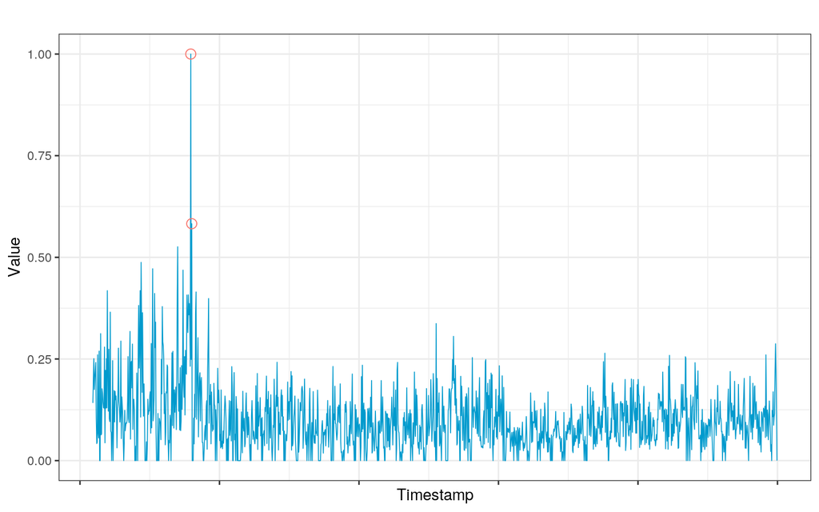

```r
plot_ts <- function(series, title="") {
  # Create a copy of timse series with normal values set to NA
  series$timestamp <- as.numeric(series$timestamp)
  outliers_NA <- series
  outliers_NA$value[which(outliers_NA$is_anomaly == 0)] <- NA

  # ggplot default color:
  # - bluish green: #00BFC4
  # - vermillion: #F8766D
  ggplot(series, aes(x = timestamp, y = value)) +
    ggtitle(title) +
    geom_line(size = 0.3, color = "deepskyblue3") +
    geom_point(outliers_NA, mapping = aes(x = timestamp, y = value, color = "red"),
               size = 3, shape = 1) +
    scale_x_continuous(expand = c(0.01, 0)) +
    scale_x_reverse() +
    scale_y_continuous(expand = c(0.05, 0)) +
    theme_bw() +
    theme(axis.text.x = element_blank()) +
    theme(legend.position = "none") +
    labs(x = "Timestamp", y = "Value", color = "Anomaly")
}

normalize <- function(x) {
  x_std <- (x - min(x)) / max(x) - min(x)
}

# Set working time series
series <- dataset[[1]]
series$value <- normalize(series$value)
plot_ts(series)
```

Let’s add some histograms

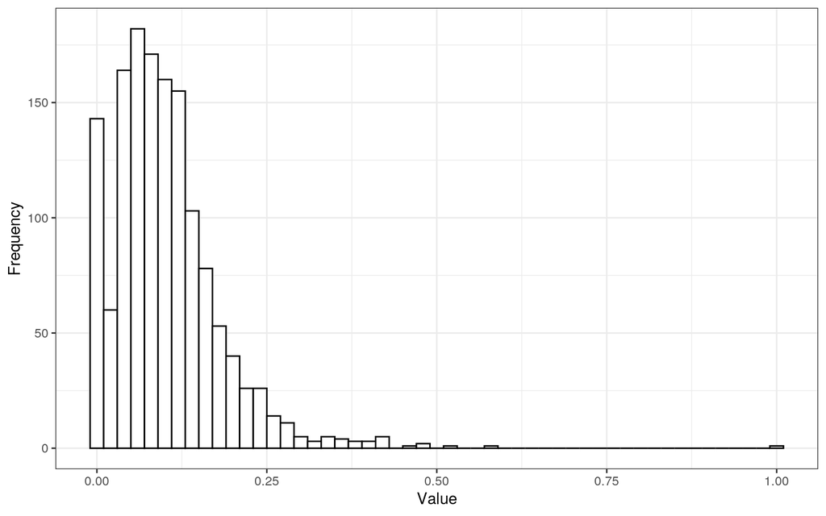

```r
plot_hist <- function(series, binsize = 1) {
  ggplot(series, aes(x = value)) +
    geom_histogram(binwidth = binsize, fill = "white", color = "black") +
    theme_bw() +
    labs(x = "Value", y = "Frequency", color = "Anomaly")
}

# Histogram of untrasformed data
plot_hist(series, 0.02)
```

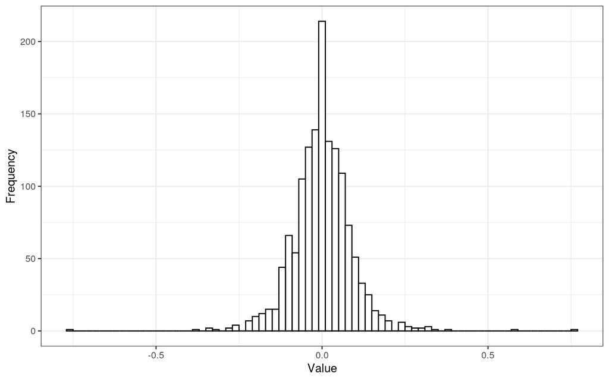

```r
# Difference the data
diffs <- data.frame(series %>% map(diff))
plot_hist(diffs, 0.02)
```

Test if time series is stationary.

```r
adf.test(series$value)
```

```
##
##  Augmented Dickey-Fuller Test
##
## data:  series$value
## Dickey-Fuller = -8.3958, Lag order = 11, p-value = 0.01
## alternative hypothesis: stationary
```

Test presence of autocorrelation.

```r
Box.test(series$value)
```

```
##
##  Box-Pierce test
##
## data:  series$value
## X-squared = 200.85, df = 1, p-value < 2.2e-16
```

Plotting the autocorrelation function.

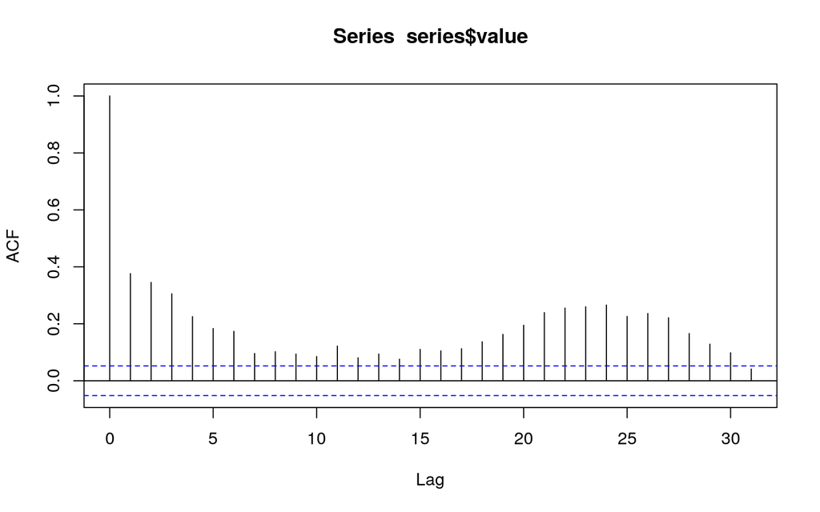

```r
acf(series$value)
```

Plotting the partial autocorrelation function.

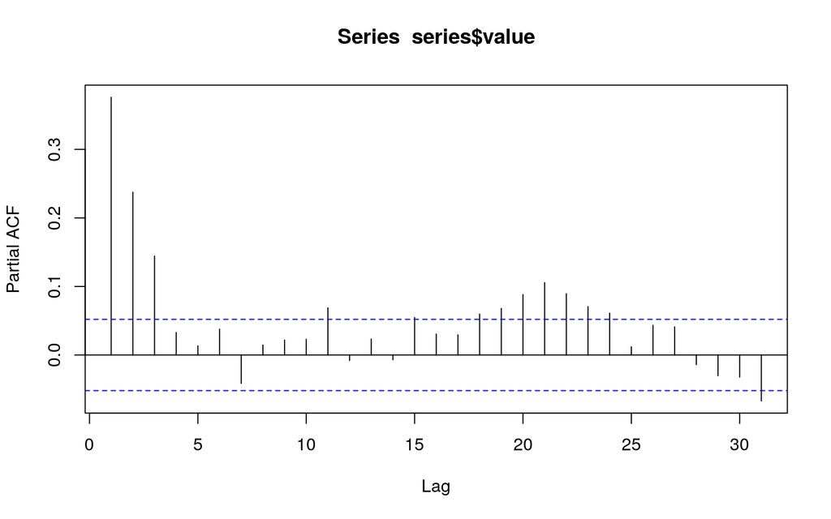

```r
pacf(series$value)
```

# Anomaly detection

## Statistical approach

We can identify anomalies using interquartile distance

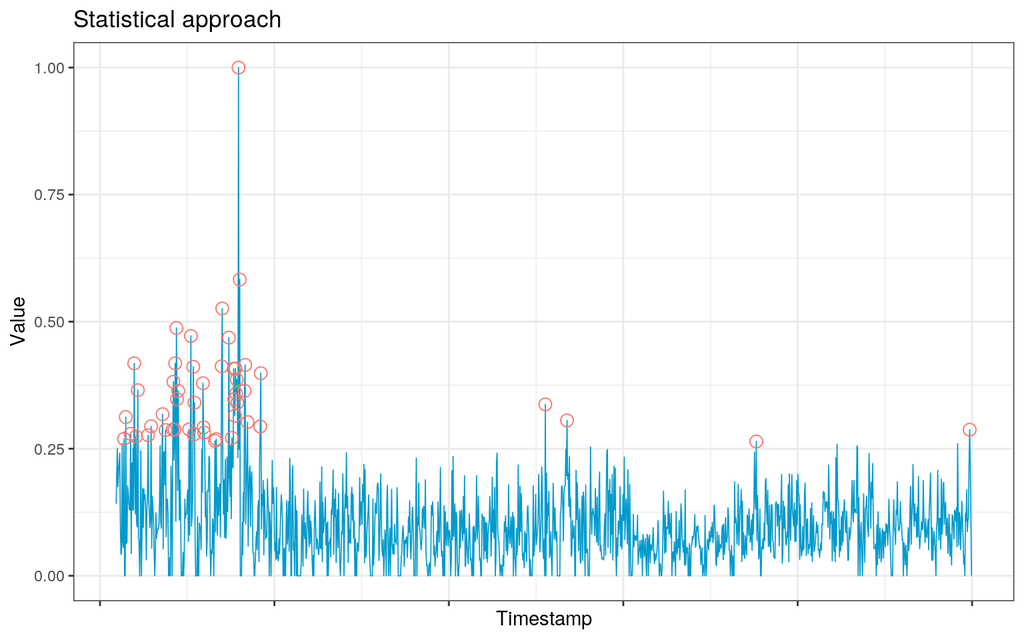

```r
anomalies_STAT <- function(series, threshold = 1.5) {
  df_stat_anom <- series %>%
  select(value) %>%
  mutate(is_low_percentile = case_when(
    value < quantile(value, probs = 0.25) - threshold * IQR(value) |
      value > quantile(value, probs = 0.75) + threshold * IQR(value)
    ~ 1,
    TRUE ~ 0
  ))
  df_stat_anom$is_low_percentile
}

series_stat <- series
series_stat$is_anomaly <- 0
series_stat["is_anomaly"] <- anomalies_STAT(series)
plot_ts(series_stat, "Statistical approach")
```

Plot confusion matrix

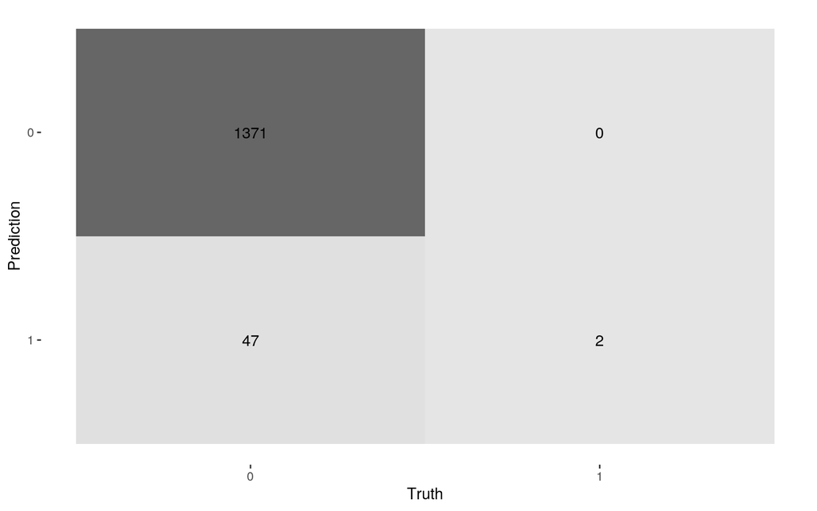

```r
plot_conf_mat <- function(truth, prediction) {
  labels = data.frame("truth" = as.factor(truth),
                      "prediction" = as.factor(prediction))
  labels %>% conf_mat(truth, prediction) %>% autoplot(type = "heatmap")
}

plot_conf_mat(series$is_anomaly, anomalies_STAT(series))
```

Calculate precision

```r
get_precision <- function(truth, prediction) {
      labels = data.frame("truth" = as.factor(truth),
                      "prediction" = as.factor(prediction))
    labels %>% precision(truth, prediction)
}

get_precision(series$is_anomaly, series_stat$is_anomaly) %>% print()
```

```
## # A tibble: 1 x 3
##   .metric   .estimator .estimate
##   <chr>     <chr>          <dbl>
## 1 precision binary             1
```

Calculate recall

```r
get_recall <- function(truth, prediction) {
    labels = data.frame("truth" = as.factor(truth),
                      "prediction" = as.factor(prediction))
    labels %>% recall(truth, prediction)
}

get_recall(series$is_anomaly, anomalies_STAT(series)) %>% print()
```

```
## # A tibble: 1 x 3
##   .metric .estimator .estimate
##   <chr>   <chr>          <dbl>
## 1 recall  binary         0.967
```

Calculate F1 score

```r
get_f_score <- function(truth, prediction) {
    labels = data.frame("truth" = as.factor(truth),
                      "prediction" = as.factor(prediction))
    labels %>% f_meas(truth, prediction)
}

get_f_score(series$is_anomaly, anomalies_STAT(series)) %>% print()
```

```
## # A tibble: 1 x 3
##   .metric .estimator .estimate
##   <chr>   <chr>          <dbl>
## 1 f_meas  binary         0.983
```

Calculate precision and recall based on the threashold. Usually this is done by shifting probability/scores threshold, thus lowering/increasing precision and recall values. In IQR method there is no probability/scores of the value being identified as an anomaly. We still try to find what are precision/recall values based on IQR coefficient threashold. We aren’t sure if this method of plotting P-R curve is correct.

```r
pr_curve_stat <- function(series, dt = 0.1) {

  # Initialize empty precision and recall vector values
  precision_values <- c(1)
  recall_values <- c(0)

  # Set cutoff threashold and precision to 0
  curr_recall <- 0
  curr_threshold <- 0

  # Iterate until recall equals 1
  while(curr_recall < 1){

    # Update threshold
    curr_threshold <- curr_threshold + dt

    # Find anomalies
    predicted_anomalies <- anomalies_STAT(series, curr_threshold)

    # Calculate precision and recall
    curr_precision <- get_precision(series$is_anomaly, predicted_anomalies)[[3]]
    curr_recall <- get_recall(series$is_anomaly, predicted_anomalies)[[3]]

    # Append current precision and recall values
    precision_values[length(precision_values) + 1] <- curr_precision
    recall_values[length(recall_values) + 1] <- curr_recall
    # print(paste("Precision: ", curr_precision))
    # print(paste("Recall: ", curr_recall))
    # print(" === ")
  }
  return (data.frame(precision = precision_values,
                   recall = recall_values))
}

pr_values <- pr_curve_stat(series, 0.01)
```

Plot precision-recall curve

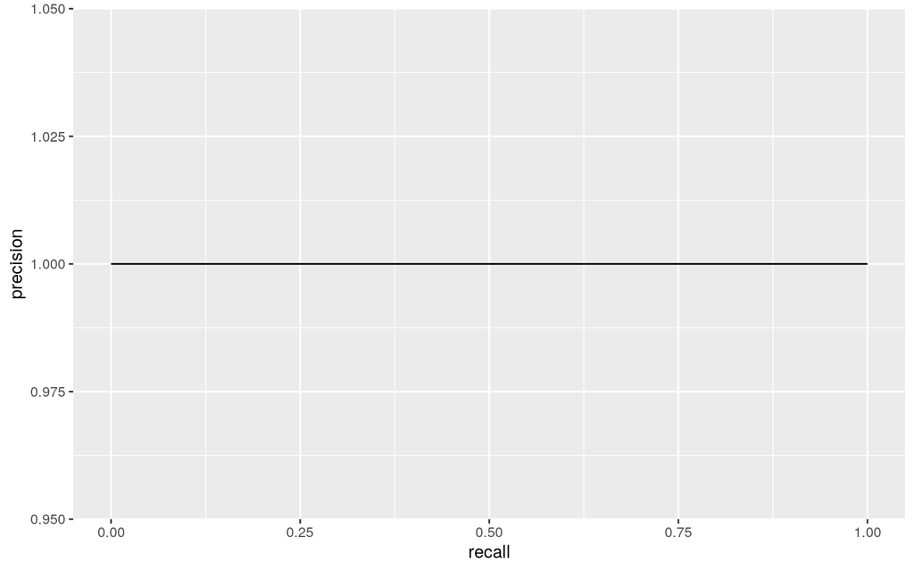

```r
ggplot(pr_values, aes(x = recall, y = precision)) +
  geom_line()
```

## One Class SVM

Grid search

```r
# Grid search parameters
gs <- list(window = c(5, 7, 10),
           nu = c(0.05, 0.01, 0.1, 0.2),
           kernel = c("radial", "sigmoid", "polynomial", "linear")) %>% cross_df

gs <- data.frame(gs)

# Intialize and train model based on provided hyperparameters
# Return corresponding outliers
ocsmv_outliers <- function(series, window, nu, kernel){

  # Embedding dimensions of the time series
  series_embeddings <- embed(series$value, window)

  # Create model based on the paramters
  model_ocsmv <- svm(series_embeddings,
                   type = 'one-classification',
                   kernel = kernel,
                   gamma = 0.05,
                   nu = nu)

  # Train model
  pred_ocsvm <- predict(model_ocsmv, series_embeddings)

  # Store detected outliers in new time series
  series_ocsvm <- series
  series_ocsvm$is_anomaly <- 0
  for (idx in which(pred_ocsvm == FALSE)){
    series_ocsvm$is_anomaly[idx:idx+4] = 1
  }
  series_ocsvm
}

gs$scores <- 0
for (idx in 1:nrow(gs)){
  outliers <- ocsmv_outliers(series, gs[idx, ]$window, gs[idx, ]$nu, gs[idx, ]$kernel)
  gs$scores[idx] <- get_f_score(series$is_anomaly, outliers$is_anomaly)[[3]]
}

print(gs[order(gs$scores, decreasing = TRUE), ])
```

```
##    window   nu     kernel    scores
## 18     10 0.01    sigmoid 0.9953950
## 17      7 0.01    sigmoid 0.9950425
## 16      5 0.01    sigmoid 0.9946865
## 4       5 0.01     radial 0.9932552
## 5       7 0.01     radial 0.9928977
## 6      10 0.01     radial 0.9893162
## 2       7 0.05     radial 0.9754335
## 1       5 0.05     radial 0.9746927
## 3      10 0.05     radial 0.9746927
## 14      7 0.05    sigmoid 0.9746927
## 15     10 0.05    sigmoid 0.9746927
## 13      5 0.05    sigmoid 0.9743404
## 28      5 0.01 polynomial 0.9512555
## 8       7 0.10     radial 0.9492405
```

[output cut: 34 more lines]

Embeding time series values

```r
series_embeddings <- embed(series$value, 5)
data.frame(t(series_embeddings[1, ]))
```

```
##          X1        X2        X3        X4 X5
## 1 0.2240529 0.2873989 0.2188933 0.1165733  0
```

```r
model_ocsmv <- svm(series_embeddings,
                   type = 'one-classification',
                   kernel = 'radial',
                   gamma = 0.05,
                   nu = 0.01)
model_ocsmv
```

```
##
## Call:
## svm.default(x = series_embeddings, type = "one-classification", kernel = "radial",
##     gamma = 0.05, nu = 0.01)
##
##
## Parameters:
##    SVM-Type:  one-classification
##  SVM-Kernel:  radial
##       gamma:  0.05
##          nu:  0.01
##
## Number of Support Vectors:  27
```

Identifying outliers using above model

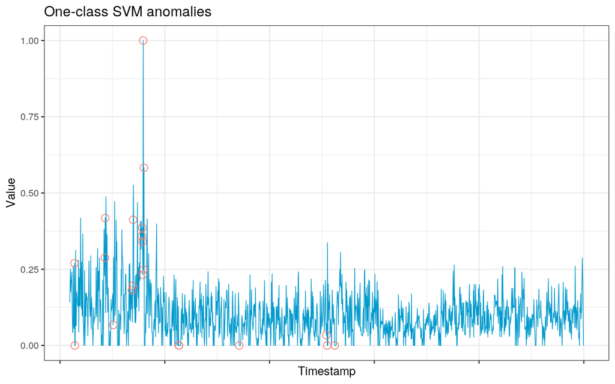

```r
pred_ocsvm <- predict(model_ocsmv, series_embeddings)

series_ocsvm <- series
series_ocsvm$is_anomaly <- 0
for (idx in which(pred_ocsvm == FALSE)){
  series_ocsvm$is_anomaly[idx:idx+4] = 1
}
plot_ts(series_ocsvm, "One-class SVM anomalies")
```

Confusion matrix

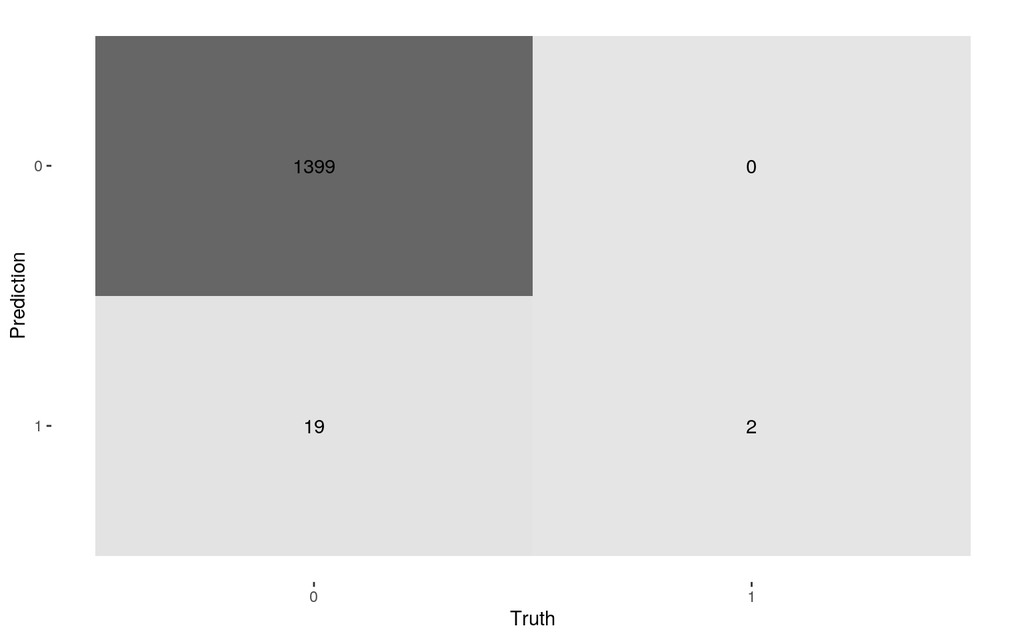

```r
plot_conf_mat(series$is_anomaly, series_ocsvm$is_anomaly)
```

Precisions

```r
get_precision(series$is_anomaly, series_ocsvm$is_anomaly) %>% print()
```

```
## # A tibble: 1 x 3
##   .metric   .estimator .estimate
##   <chr>     <chr>          <dbl>
## 1 precision binary             1
```

Recall

```r
get_recall(series$is_anomaly, series_ocsvm$is_anomaly) %>% print()
```

```
## # A tibble: 1 x 3
##   .metric .estimator .estimate
##   <chr>   <chr>          <dbl>
## 1 recall  binary         0.987
```

F1 score

```r
get_f_score(series$is_anomaly, series_ocsvm$is_anomaly) %>% print()
```

```
## # A tibble: 1 x 3
##   .metric .estimator .estimate
##   <chr>   <chr>          <dbl>
## 1 f_meas  binary         0.993
```

## Seasonal Hybrid ESD model

Find and plot anomalies using Hybrid ESD.

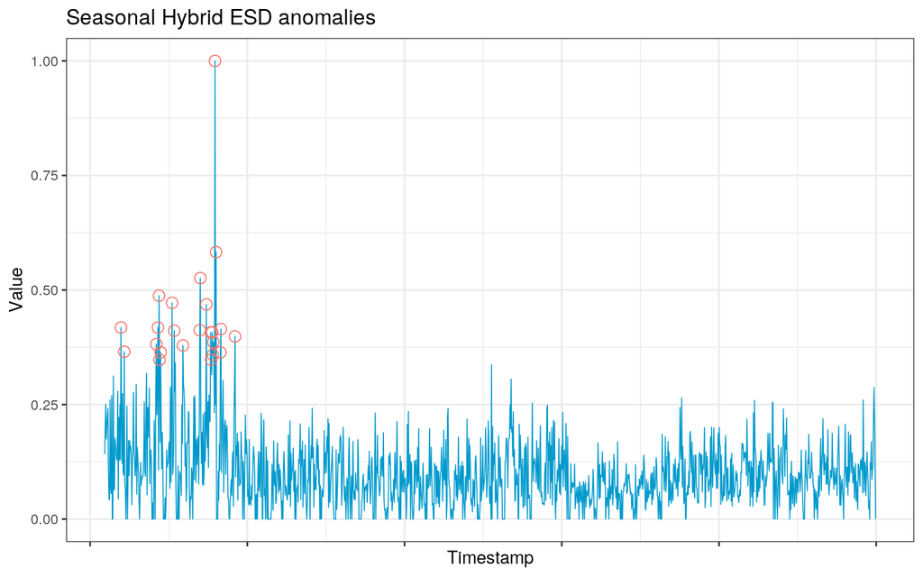

```r
anomalies_ESD <- function(series) {
  # Leave only timestamp and value columns
  data = data.frame(series$timestamp, series$value)

  # Find and plot anomalies
  res = AnomalyDetectionTs(data,
                           max_anoms = 0.02,
                           direction = "both",
                           plot = TRUE)
  series_esd <- series
  series_esd$is_anomaly <- 0
  series_esd$is_anomaly[as.numeric(series$timestamp) %in% as.numeric(res$anoms$timestamp)] <- 1
  return(series_esd)
}

# Plot Hybrid ESD anomalies
anoms_esd = anomalies_ESD(series)
plot_ts(anoms_esd, "Seasonal Hybrid ESD anomalies")
```

Confusion matrix

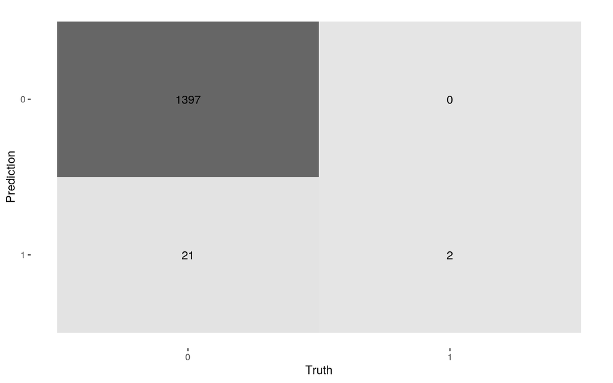

```r
plot_conf_mat(series$is_anomaly, anoms_esd$is_anomaly)
```

Precisions

```r
get_precision(series$is_anomaly, anoms_esd$is_anomaly) %>% print()
```

```
## # A tibble: 1 x 3
##   .metric   .estimator .estimate
##   <chr>     <chr>          <dbl>
## 1 precision binary             1
```

Recall

```r
get_recall(series$is_anomaly, anoms_esd$is_anomaly) %>% print()
```

```
## # A tibble: 1 x 3
##   .metric .estimator .estimate
##   <chr>   <chr>          <dbl>
## 1 recall  binary         0.985
```

F1 score

```r
get_f_score(series$is_anomaly, anoms_esd$is_anomaly) %>% print()
```

```
## # A tibble: 1 x 3
##   .metric .estimator .estimate
##   <chr>   <chr>          <dbl>
## 1 f_meas  binary         0.993
```

## ARIMA model

### Predicting anomalies

Fitting an ARIMA Model.

```r
yahoo_m <- auto.arima(series$value, seasonal = FALSE)
yahoo_m
```

```
## Series: series$value
## ARIMA(1,1,5)
##
## Coefficients:
##          ar1      ma1     ma2      ma3      ma4      ma5
##       0.5660  -1.3381  0.4322  -0.0124  -0.0572  -0.0085
## s.e.  0.1241   0.1259  0.1076   0.0460   0.0419   0.0356
##
## sigma^2 estimated as 0.005042:  log likelihood=1741.57
## AIC=-3469.13   AICc=-3469.05   BIC=-3432.33
```

Running diagnosis on an ARIMA model.

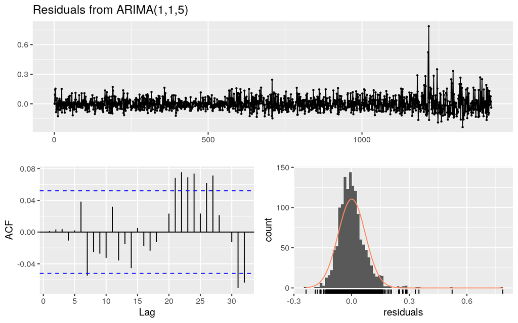

```
##
##  Ljung-Box test
##
## data:  Residuals from ARIMA(1,1,5)
## Q* = 10.096, df = 4, p-value = 0.03885
##
## Model df: 6.   Total lags used: 10
```

```r
checkresiduals(yahoo_m)
```

Make forecast with ARIMA model.

```r
fc_yahoo_m <- forecast(yahoo_m, 20)
fc_yahoo_m
```

```
##      Point Forecast      Lo 80     Hi 80         Lo 95     Hi 95
## 1421      0.1664443 0.07544081 0.2574478  2.726646e-02 0.3056222
## 1422      0.1591098 0.06577295 0.2524467  1.636340e-02 0.3018562
## 1423      0.1535164 0.05799658 0.2490362  7.431432e-03 0.2996014
## 1424      0.1523741 0.05499624 0.2497519  3.447533e-03 0.3013006
## 1425      0.1520568 0.05382138 0.2502923  1.818658e-03 0.3022950
## 1426      0.1518773 0.05324895 0.2505057  1.038243e-03 0.3027164
## 1427      0.1517757 0.05293721 0.2506142  6.152769e-04 0.3029361
## 1428      0.1517182 0.05274772 0.2506887  3.559166e-04 0.3030805
## 1429      0.1516856 0.05261937 0.2507519  1.768523e-04 0.3031944
## 1430      0.1516672 0.05252306 0.2508114  3.931755e-05 0.3032951
## 1431      0.1516568 0.05244408 0.2508695 -7.595231e-05 0.3033895
## 1432      0.1516509 0.05237466 0.2509271 -1.790042e-04 0.3034808
## 1433      0.1516475 0.05231057 0.2509845 -2.752498e-04 0.3035703
## 1434      0.1516457 0.05224949 0.2510418 -3.676638e-04 0.3036590
## 1435      0.1516446 0.05219012 0.2510991 -4.579012e-04 0.3037471
## 1436      0.1516440 0.05213172 0.2511562 -5.468895e-04 0.3038348
## 1437      0.1516436 0.05207389 0.2512134 -6.351508e-04 0.3039224
## 1438      0.1516434 0.05201639 0.2512705 -7.229794e-04 0.3040099
## 1439      0.1516433 0.05195910 0.2513276 -8.105417e-04 0.3040972
## 1440      0.1516433 0.05190194 0.2513846 -8.979318e-04 0.3041845
```

Plotting the forecast.

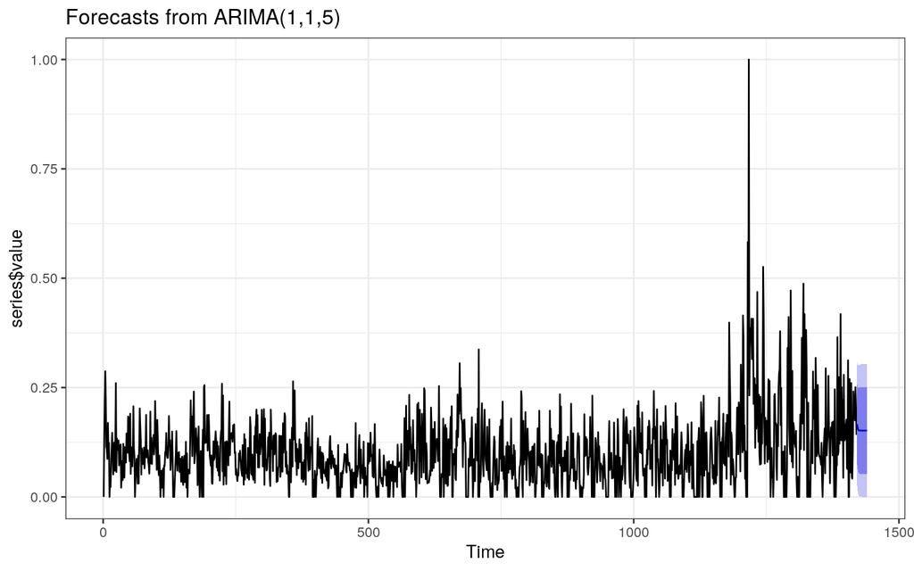

```r
ts_length = length(fc_yahoo_m$x)

# Plot ARIMA forecast
autoplot(fc_yahoo_m) +
  theme_bw()
```

### Identifying anomalies

For some reason ARIMA model can’t forecast time series value beyound 10 steps. As seen on forecasting plot the forecast in smoothed out.

## Machine learning models

### Isolation forests

Detecting anomalies with isoaltion forests using `solitude` library

```r
anomalies_ISO <- function(series, threashold=0.5) {
  # Isolation forests model instance
  iso <- isolationForest$new()

  # Fit for time series values data
  iso$fit(data.frame(series$value))

  # Identify anomalies score above the threashold
  iso_anomalies <- if_else(iso$scores$anomaly_score > threashold, 1, 0)
}

anomalies_ISO_scores <- function(series){
    # Isolation forests model instance
  iso <- isolationForest$new()

  # Fit for time series values data
  iso$fit(data.frame(series$value))
  data.frame(truth = as.factor(series$is_anomaly),
             estimate = 1 - iso$scores$anomaly_score)
}
```

```r
scores_iso <- anomalies_ISO_scores(series)
```

```
## Building Isolation Forest ... done
## Computing depth of terminal nodes ... done
```

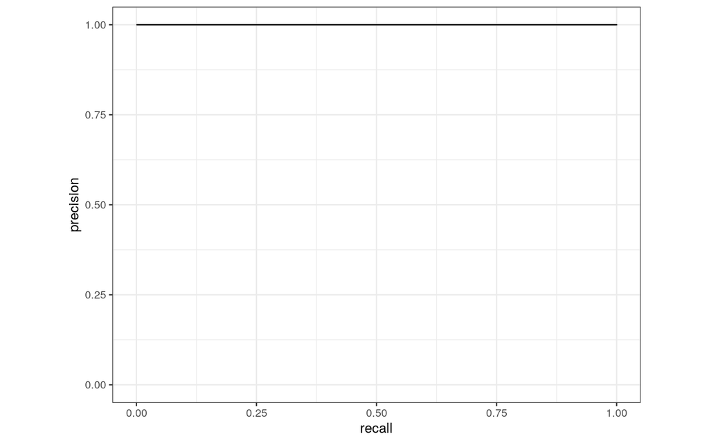

```r
pr_curve(scores_iso, truth, estimate) %>% autoplot()
```

```r
threashold = 0.6
series_iso <- series
series_iso["is_anomaly"] <- anomalies_ISO(series, threashold)
```

```
## Building Isolation Forest ... done
## Computing depth of terminal nodes ... done
```

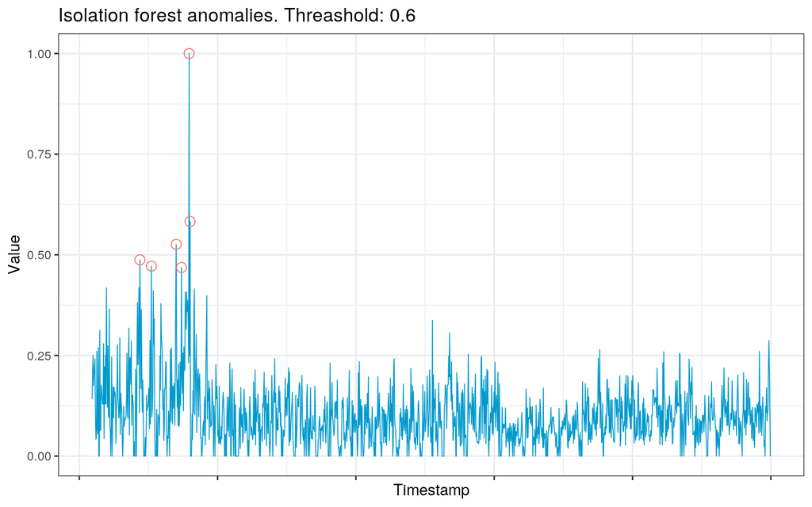

```r
plot_ts(series_iso, paste("Isolation forest anomalies. Threashold:", threashold))
```

Confusion matrix

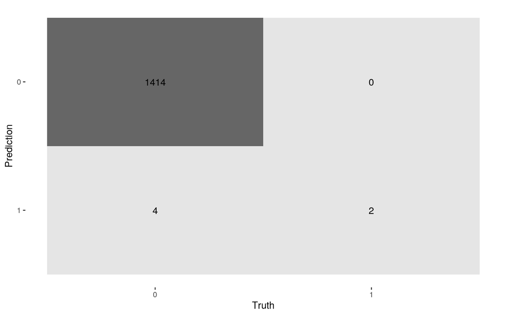

```r
plot_conf_mat(series$is_anomaly, series_iso$is_anomaly)
```

Precisions

```r
get_precision(series$is_anomaly, series_iso$is_anomaly) %>% print()
```

```
## # A tibble: 1 x 3
##   .metric   .estimator .estimate
##   <chr>     <chr>          <dbl>
## 1 precision binary             1
```

Recall

```r
get_recall(series$is_anomaly, series_iso$is_anomaly) %>% print()
```

```
## # A tibble: 1 x 3
##   .metric .estimator .estimate
##   <chr>   <chr>          <dbl>
## 1 recall  binary         0.997
```

F1 score

```r
get_f_score(series$is_anomaly, series_iso$is_anomaly) %>% print()
```

```
## # A tibble: 1 x 3
##   .metric .estimator .estimate
##   <chr>   <chr>          <dbl>
## 1 f_meas  binary         0.999
```